# ps9_solutions

Source `PSet9_code.m`, `Pset9_Q2_Alternative.m` github

## **1. Computing policies for the monetary model (100 points)**

In class, we have considered a monetary model where the Bellman equation is given by:

$$ V(m, \theta) = \max_{c, m'} \left[ \theta u(c) + \beta \sum_{\theta' \in \Theta} V(m', \theta') Q(\theta, \theta') \right], $$

subject to:

$$ m' = \frac{m}{1 + \gamma} - c + y + \tau $$

and subject to the Cash-in-Advance (CIA) constraint:

$$ c \leq \frac{m}{1 + \gamma} $$

Assume that the utility function is given by:

$$ u(c) = \frac{c^{1-\sigma}}{1-\sigma}, $$

and that the parameters are:

- $\sigma = 2 $
- $\beta = 0.98$
- $y = 1 $
- $\gamma = 0.02 $
- $\tau = 0.0234$

Assume also two possible values for the shock:

$$ \Theta = \{ \theta_1, \theta_2 \} = \{0.74, 1.36\} $$

and the Markov transition matrix is given by:

$$ Q(\theta, \theta') = Pr(\theta' | \theta) \equiv \begin{bmatrix} Pr(\theta_1 | \theta_1) & Pr(\theta_2 | \theta_1) \\ Pr(\theta_1 | \theta_2) & Pr(\theta_2 | \theta_2) \end{bmatrix} = \begin{bmatrix} 0.73 & 0.27 \\ 0.27 & 0.73 \end{bmatrix} $$

### **Tasks**

**(a)** Use a grid of 1000 points to solve for the policy functions $g(m, \theta)$, $c(m, \theta)$ using **Value Function Iteration (VFI)**. (50 points)

```
Convergence achieved
```

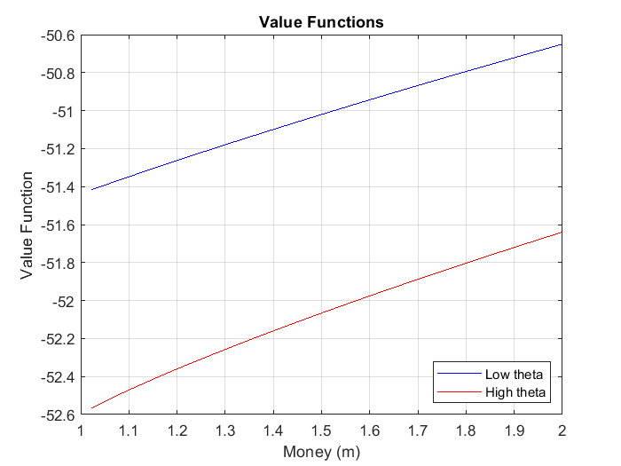

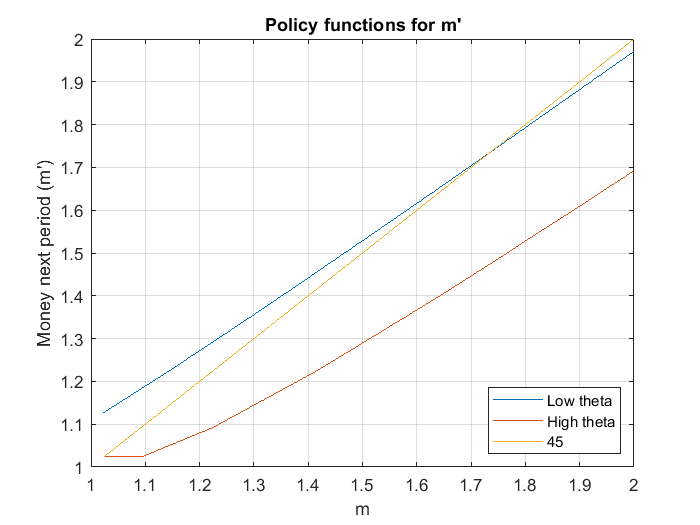

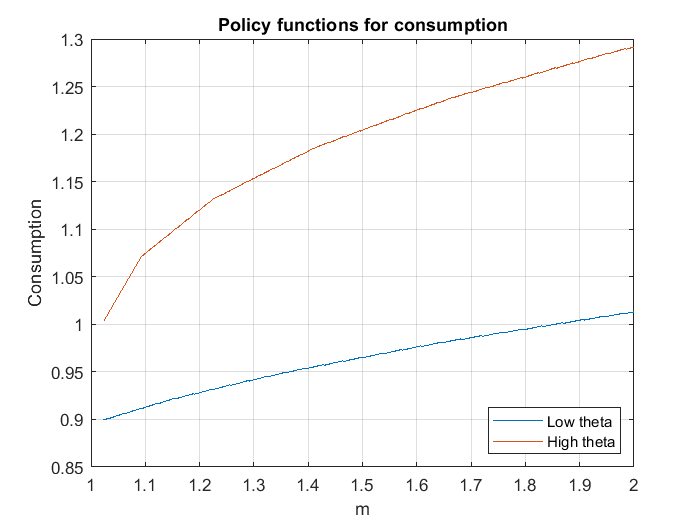

```matlab
%% Policy functions VFI

% Parameters
beta = 0.98;
sigma = 2;
y = 1; % Fixed endowment
tau = 0.0234;
gamma = 0.02;
theta_1 = 0.74;
theta_2 = 1.36;

% Transition matrix
% Transition prob starting on theta_1
p11 = 0.73;
p21 = 1 - p11;

% Transition probabilities starting in theta_2
p22 = 0.73;
p12 = 1 - p22;

Np = 1000; % Size of the grid
mp_min = y + tau; % CIA constraint (m' = y + tau)
mp_max = 2;  % Maximum money level (optional)

% Create the grid of a
mgrid = linspace(mp_min, mp_max, Np)';

% Maximum number of iterations
Nk = 1000;

% consumption has a direct correspondence with the other variables
% endowment is fixed
c0 = (mgrid ./ (1 + gamma)) + y + tau - mgrid';

% If any of the above are negative, replace with zero
c0(c0 < 0) = 0;

% Define the matrices of returns
ut_c = u_t(sigma, c0);

% Definition of placeholders for Value Functions
g_1 = zeros(Np, Nk);
g_2 = zeros(Np, Nk);

% Initial guess for value function (V(m',theta'))
g_1(:,1) = real(u_t(sigma, mgrid));
g_2(:,1) = real(u_t(sigma, mgrid));

% Define the utility function
function result = u_t(sigma, c)
    % Ensure no log of negative or zero values
    c(c <= 0) = 1e-6;
    if abs(sigma - 1) == 0
        result = log(c); % Log utility for sigma = 1
    else
        result = (c.^(1 - sigma)) / (1 - sigma); % CRRA utility
    end
end
% Iterations to fill vf with the maximum
for i = 1:Nk-1
    % Compute value functions
    % VF = theta * u(c) + beta * sum[VF(m',theta')*Q(theta, theta')]
    % Where VF(m',theta') is g_1 or g_2, respectively
    VF_1 = theta_1 * ut_c + (beta * p11 * g_1(:,i)' + beta * p12 * g_2(:,i)');
    VF_2 = theta_2 * ut_c + (beta * p21 * g_1(:,i)' + beta * p22 * g_2(:,i)');

    % Solve for the next period value function
    [g_1(:, i+1), mind_1] = max(VF_1');
    [g_2(:, i+1), mind_2] = max(VF_2');

    % Check for convergence
    vdiff = [g_1(:, i+1); g_2(:, i+1)] - [g_1(:, i); g_2(:, i)];
    if max(abs(vdiff)) <= 0.001 * (1 - beta)
        disp("Convergence achieved");
        conv = i;
        break;
    end
end

% Computing the policy functions

% Define the assets placeholders
mpol_1 = zeros(Np, 1);
mpol_2 = zeros(Np, 1);

for i = 1:Np
    mpol_1(i) = mgrid(mind_1(i));
    mpol_2(i) = mgrid(mind_2(i));
end


% Define the consumption
cpol_1 = (mgrid ./ (1 + gamma)) + y + tau - mpol_1;
cpol_2 = (mgrid ./ (1 + gamma)) + y + tau - mpol_2;

% Plotting value functions
figure;
plot(mgrid, g_1(:, conv), 'b'); hold on;
plot(mgrid, g_2(:, conv), 'r');
grid;
xlabel('Money (m)');
ylabel('Value Function');
title('Value Functions');
legend({'Low theta', 'High theta'}, 'location', 'southeast');
hold off;

% Plotting policy functions for money
figure;
plot(mgrid, mpol_1); hold on;
plot(mgrid, mpol_2); hold on;
plot(mgrid, mgrid)
grid;
xlabel('m');
ylabel("Money next period (m')");
title("Policy functions for m'");
legend({'Low theta', 'High theta', '45'}, 'location', 'southeast');

% Plotting policy functions for consumption
figure;
plot(mgrid, cpol_1); hold on;
plot(mgrid, cpol_2);
grid;
xlabel('m');
ylabel('Consumption');
title('Policy functions for consumption');
legend({'Low theta', 'High theta'}, 'location', 'southeast');
```

**(b)** Use a grid of 1000 points to solve for the policy functions $g(m, \theta), c(m, \theta)$ using **Endogenous Grid Method (EGM)**. (50 points)

```
Convergence achieved after 69 iterations.
```

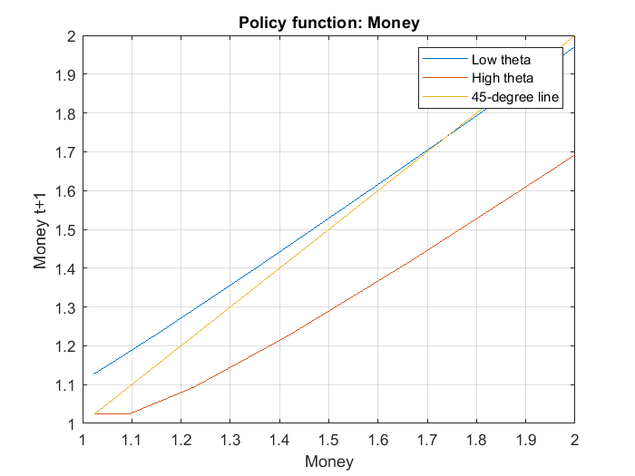

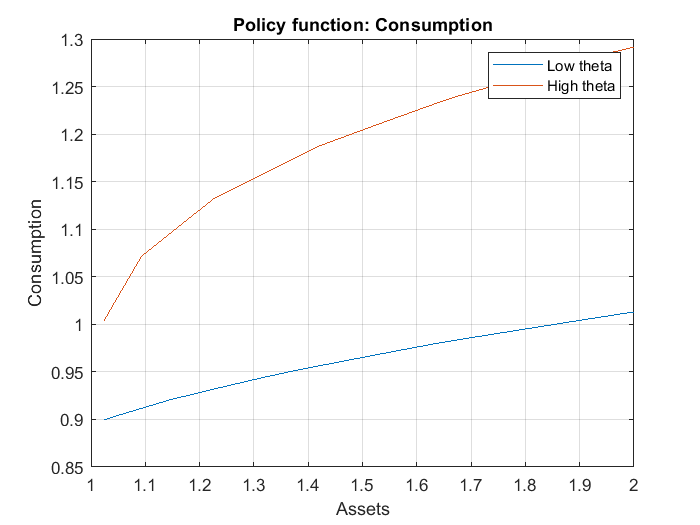

```matlab
%% Policy functions EGM

% Parameters
beta = 0.98;
sigma = 2;
y = 1; % Fixed endowment
tau = 0.0234;
gamma = 0.02;
theta_1 = 0.74;
theta_2 = 1.36;

% Transition matrix
% Transition prob starting on theta_1
p11 = 0.73;
p21 = 1 - p11;

% Transition probabilities starting in theta_2
p22 = 0.73;
p12 = 1 - p22;

Np = 1000; % Size of the grid
mp_min = y + tau; % CIA constraint (m' = y + tau)
mp_max = 2;  % Maximum money level (optional)

% Create the grid of m
mgrid = linspace(mp_min, mp_max, Np)';

% Maximum number of iterations
Nk = 1000;

% Initial guesses of m
g0_1 = mgrid;
g0_2 = mgrid;

% Preallocate memory for future iterations
g_1 = zeros(Np, Nk);
g_2 = zeros(Np, Nk);

% First column is the initial guess
g_1(:,1) = g0_1;
g_2(:,1) = g0_2;

for j = 1:Nk-1
    uprime_1 = theta_1 * ((mgrid ./ (1 + gamma)) + y + tau - g_1(:,j)) .^ (-sigma);
    uprime_2 = theta_2 * ((mgrid ./ (1 + gamma)) + y + tau - g_2(:,j)) .^ (-sigma);

    % Compute expectations under the Markov transition matrix
    EV_1 = ((beta/(1+gamma)) * (p11 * uprime_1' + p12 * uprime_2'))';
    EV_2 = ((beta/(1+gamma)) * (p21 * uprime_1' + p22 * uprime_2'))';

    % Compute mstar
    ms_1 = ((EV_1/theta_1) .^ (-1/sigma) + mgrid - y - tau) * (1+gamma);
    ms_2 = ((EV_2/theta_2) .^ (-1/sigma) + mgrid - y - tau) * (1+gamma);

    for i=1:Np
        if mgrid(i) <= ms_1(1)
            g_1(i,j+1) = mgrid(1);
        elseif mgrid(i) >= ms_1(Np)
            g_1(i, j+1) = mgrid(Np);
        else
            g_1(i, j+1) = interp1(ms_1, mgrid, mgrid(i), 'linear', 'extrap');
        end
    end

    for i=1:Np
        if mgrid(i) <= ms_2(1)
            g_2(i,j+1) = mgrid(1);
        elseif mgrid(i) >= ms_2(Np)
            g_2(i, j+1) = mgrid(Np);
        else
            g_2(i, j+1) = interp1(ms_2, mgrid, mgrid(i), 'linear', 'extrap');
        end
    end

    % Check convergence
    gdiff = max(abs([g_1(:,j+1); g_2(:,j+1)] - [g_1(:,j); g_2(:,j)]));
    if gdiff <= 1e-10
        disp("Convergence achieved after " + num2str(j) + " iterations.");
        g_pol_1 = g_1(:, j+1);
        g_pol_2 = g_2(:, j+1);
        break;
    end
end

% If convergence isn't achieved, store final iteration values
if gdiff > 1e-10
    disp("Maximum iterations reached without convergence.");
    g_pol_1 = g_1(:, end);
    g_pol_2 = g_2(:, end);
end


% Compute policy functions for consumption
c_pol_1 = (mgrid / (1 + gamma)) + y + tau - g_pol_1;
c_pol_2 = (mgrid / (1 + gamma)) + y + tau - g_pol_2;


% Plotting money policy function
figure;
plot(mgrid, g_pol_1); hold on;
plot(mgrid, g_pol_2);
plot(mgrid, mgrid); % 45-degree line
grid on;
xlabel('Money');
ylabel('Money t+1');
legend('Low theta', 'High theta', '45-degree line');
title('Policy function: Money');

% Plotting consumption policy function
figure;
plot(mgrid, c_pol_1); hold on;
plot(mgrid, c_pol_2);
grid on;
xlabel('Assets');
ylabel('Consumption');
legend('Low theta', 'High theta');
title('Policy function: Consumption');
```

## **2. Computing distributions (100 points)**

Once you have obtained the policies $ g(m, \theta_1) $ and $ g(m, \theta_2) $, in this exercise you will compute distributions. Consider all information regarding parameters provided in Question 1. However, use a finer grid for the distributions than the one used in Question 1. Let $ \pi_1, \pi_2 $ be the ergodic distribution corresponding to the matrix $ Q(\theta, \theta') $.

**(a)** Consider the following recursions:

$$ \Psi_{s+1}(m', \theta_j) = \Psi_s \left( g^{-1}(m', \theta_j), \theta_j \right) $$

with the initial distribution given by:

$$ \Psi_0(m_i, \theta_j) = \left\{ \Psi_0(m_1, \theta_j) + [\Psi_0(m_M, \theta_j) - \Psi_0(m_1, \theta_j)] \frac{m_i - m_1}{m_M - m_1} \right\} \times \pi_j $$

where:

$$ \Psi_0(m_1, \theta_j) = 0, \quad \Psi_0(m_M, \theta_j) = 1. $$

Find the limiting distributions for each case ($ j = 1, 2 $), by iterating on the recursions. (50 points)

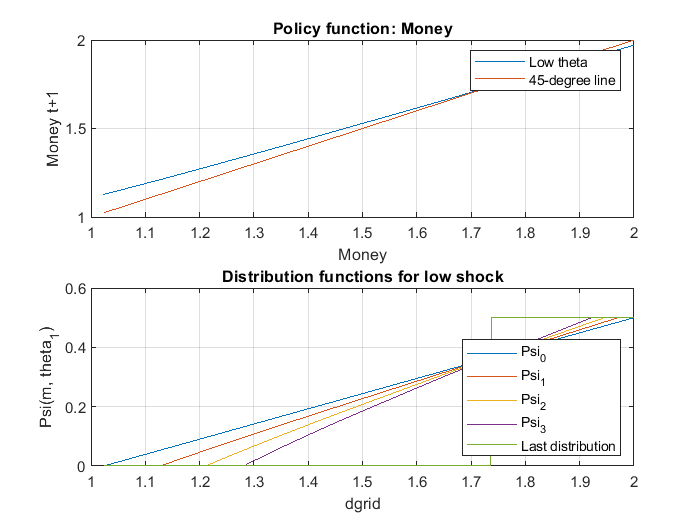

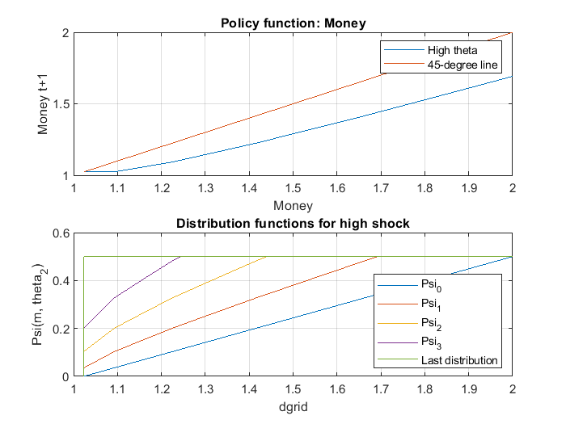

```matlab
%% Computing distributions a)
% Parameters are the same for the policy functions

% Distribution parameters
% New grid for the distribution
Dp = 2*Np-1;
dist_mgrid = linspace(mp_min, mp_max, Dp)';

Dk = 1000; % Maximum number of distribution iterations

% Other options: normal dist
unif_dist = (dist_mgrid - dist_mgrid(1)) / (dist_mgrid(Dp) - dist_mgrid(1));


% Create a transition matrix with the prob
QQ = [p11 p21; p12 p22];
nshocks = 2;

% Create the ergodic distribution (cn 7)
% The ergodic distribution (or stationary distribution) of a Markov chain
% represents the long-run probability of being in each state when the system
% reaches equilibrium. It tells us how often, on average, we would expect the
% system to be in each state after a long enough period.

% Linearization of the system of equations (eye is the identity matrix of
% size nshocks)
% pi1 = 0.73 * pi1 + 0.27 * pi2
% pi2 = 0.27 * pi1 + 0.73 * pi2

prob = QQ - eye(nshocks);
% [(0.73 - 1)  0.27]
% [0.27  (0.73 - 1)]

% but this has infinite solutions, hence we first enforce pi1 + pi2 = 1
% by enforcing the last column to be 1 (normalization condition)
% This is the same as normalizing the eigenvector to sum to 1 in tauchen's
% [-0.27  1]
% [ 0.27  1]

prob(:, nshocks) = ones(nshocks, 1);

% On the other side of the equality, we would have a = [0 1] to solve
% for the ergodic distribution over states that remain unchanged over the
% long run and sum up to 1

a = zeros(nshocks, 1);
a(nshocks) = 1;

% Ergodic distribution
epr = linsolve(prob', a);

% Placeholders for my distributions
% initial_dist = (psi_0(m1) + [psi_0(mM) - psi_0(m1)] * unif_dist) * epr
% but since psi_0(mM)=1 and psi_0(m1)=0
F1 = zeros(Dp, Dk);
F1(:,1) = epr(1) * unif_dist; %epr(1) is for the ergodic dist for theta_1

F2 = zeros(Dp, Dk);
F2(:,1) = epr(2) * unif_dist; %epr(2) is for the ergodic dist for theta_2


% Iterations for convergence
for i = 1:Dk-1
    for j=1:Dp

        % For low shock

        if dist_mgrid(j) <= g_pol_1(1)
            val_1 = 0;
        elseif dist_mgrid(j) >= g_pol_1(Np)
            val_1 = epr(1);
        else
            % This is to obtain the unique values of the policy
            % function and extract the index for each one of these values.
            [g1r, ind_1] = unique(g_pol_1, "last");

            % For the first interpolation I want an interpolated value for dist_mgrid(j)
            % using the function values (gr1) of mgrid(ind_1).
            % For the second interpolation I want an interpolated value of
            % the distribution function F1(:,i) at that query point (new dgrid).

            % The reason g1r is X and mgrid(ind_1) is Y is because I want
            % the value in mgrid (inverse policy function used)

            % Otherwise dist_mgrid is X and F1(:,i) is Y because I
            % want the value of the distribution such that I can use it
            % as my new value of the function in i+1.

            val_1 = interp1(dist_mgrid, F1(:,i), interp1(g1r, mgrid(ind_1), dist_mgrid(j), "linear"), "linear");

        end

        % For high shock

        if dist_mgrid(j) <= g_pol_2(1)
            val_2 = 0;
        elseif dist_mgrid(j) >= g_pol_2(Np)
            val_2 = epr(2);
        else
            [g2r, ind_2] = unique(g_pol_2, "last");

            val_2 = interp1(dist_mgrid, F2(:,i), interp1(g2r, mgrid(ind_2), dist_mgrid(j), "linear"), "linear");
        end

        % New distribution
        F1(j, i+1) = val_1;
        F2(j, i+1) = val_2;

    end

    diff1 = max(abs(F1(:,i+1)-F1(:,i)));
    diff2 = max(abs(F2(:,i+1)-F2(:,i)));

    F1_dist = F1(:,i+1);
    F2_dist = F2(:,i+1);

    if diff1 <= 1e-10 && diff2 <= 1e-10
        disp("convergence achieved of F1");
        disp("convergence achieved of F2");
        disp(i);
        break
    end
end

% Plot distribution functions when they converge
figure;
subplot(2,1,1);
plot(mgrid, g_pol_1); hold on;
plot(mgrid, mgrid); % 45-degree line
grid on;
xlabel('Money');
ylabel('Money t+1');
legend('Low theta', '45-degree line');
title('Policy function: Money');

subplot(2,1,2);
plot(dist_mgrid, F1(:,1)); hold on;
plot(dist_mgrid, F1(:,2)); hold on;
plot(dist_mgrid, F1(:,3)); hold on;
plot(dist_mgrid, F1(:,4)); hold on;
plot(dist_mgrid, F1_dist);
grid on;
xlabel('dgrid');
ylabel('Psi(m, theta_1)');
title('Distribution functions for low shock');
legend({'Psi_0', 'Psi_1', 'Psi_2', 'Psi_3', 'Last distribution'}, 'location', 'southeast');

figure;
subplot(2,1,1);
plot(mgrid, g_pol_2); hold on;
plot(mgrid, mgrid); % 45-degree line
grid on;
xlabel('Money');
ylabel('Money t+1');
legend('High theta', '45-degree line');
title('Policy function: Money');

subplot(2,1,2);
plot(dist_mgrid, F2(:,1)); hold on;
plot(dist_mgrid, F2(:,2)); hold on;
plot(dist_mgrid, F2(:,3)); hold on;
plot(dist_mgrid, F2(:,4)); hold on;
plot(dist_mgrid, F2_dist);
grid on;
xlabel('dgrid');
ylabel('Psi(m, theta_2)');
title('Distribution functions for high shock');
legend({'Psi_0', 'Psi_1', 'Psi_2', 'Psi_3', 'Last distribution'}, 'location', 'southeast');
```

**(b)** Now, consider the following recursions:

$$ \Psi_{s+1}(m', \theta_j) = \sum_{\theta \in \Theta} Q(\theta, \theta_j) \Psi_s \left( g^{-1}(m', \theta), \theta \right) $$

for $ j = 1, 2 $, with initial distributions given by:

$$ \Psi_0(m_i, \theta_j) = \left\{ \Psi_0(m_1, \theta) + [\Psi_0(m_M, \theta) - \Psi_0(m_1, \theta)] \frac{m_i - m_1}{m_M - m_1} \right\} \times \pi_j $$

where:

$$ \Psi_0(m_1, \theta_j) = 0, \quad \Psi_0(m_M, \theta_j) = 1. $$

Find the limiting distributions for each case ($ j = 1, 2 $), by iterating on the recursions. (50 points)

```
convergence achieved of F2
    71
```

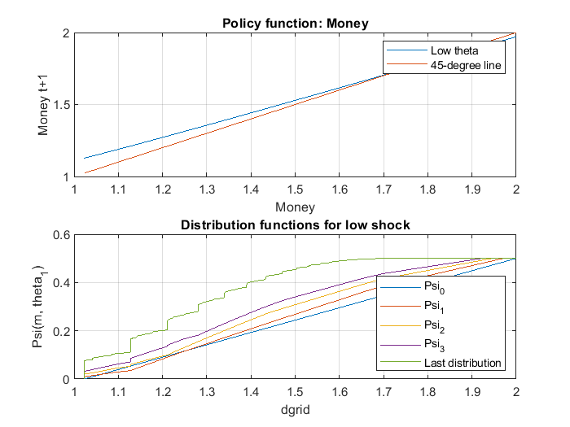

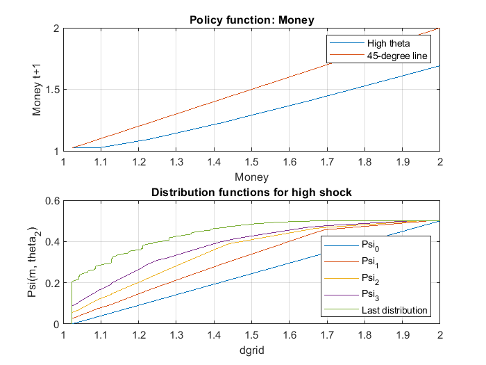

```matlab
%% Computing distributions b)

% Parameters are the same for the policy functions

% Distribution parameters
% New grid for the distribution
Dp = 2*Np-1;
dist_mgrid = linspace(mp_min, mp_max, Dp)';

Dk = 1000; % Maximum number of distribution iterations

% Other options: normal dist
unif_dist = (dist_mgrid - dist_mgrid(1)) / (dist_mgrid(Dp) - dist_mgrid(1));


% Create a transition matrix with the prob
QQ = [p11 p21; p12 p22];
nshocks = 2;

% Create the ergodic distribution (cn 7)
% The ergodic distribution (or stationary distribution) of a Markov chain
% represents the long-run probability of being in each state when the system
% reaches equilibrium. It tells us how often, on average, we would expect the
% system to be in each state after a long enough period.

% Linearization of the system of equations (eye is the identity matrix of
% size nshocks)
% pi1 = 0.73 * pi1 + 0.27 * pi2
% pi2 = 0.27 * pi1 + 0.73 * pi2

prob = QQ - eye(nshocks);
% [(0.73 - 1)  0.27]
% [0.27  (0.73 - 1)]

% but this has infinite solutions, hence we first enforce pi1 + pi2 = 1
% by enforcing the last column to be 1 (normalization condition)
% This is the same as normalizing the eigenvector to sum to 1 in tauchen's
% [-0.27  1]
% [ 0.27  1]

prob(:, nshocks) = ones(nshocks, 1);

% On the other side of the equality, we would have a = [0 1] to solve
% for the ergodic distribution over states that remain unchanged over the
% long run and sum up to 1

a = zeros(nshocks, 1);
a(nshocks) = 1;

% Ergodic distribution
epr = linsolve(prob', a);

% Placeholders for my distributions
% initial_dist = (psi_0(m1) + [psi_0(mM) - psi_0(m1)] * unif_dist) * epr
% but since psi_0(mM)=1 and psi_0(m1)=0
F1 = zeros(Dp, Dk);
F1(:,1) = epr(1) * unif_dist; %epr(1) is for the ergodic dist for theta_1

F2 = zeros(Dp, Dk);
F2(:,1) = epr(2) * unif_dist; %epr(2) is for the ergodic dist for theta_2


% Iterations for convergence
for i = 1:Dk-1
    for j=1:Dp

        % For low shock

        if dist_mgrid(j) < g_pol_1(1)
            val_1 = 0;
        elseif dist_mgrid(j) > g_pol_1(Np)
            val_1 = epr(1);
        else
            % This is to obtain the unique values of the policy
            % function and extract the index for each one of these values.
            [g1r, ind_1] = unique(g_pol_1, "last");

            % For the first interpolation I want an interpolated value for dist_mgrid(j)
            % using the function values (gr1) of mgrid(ind_1).
            % For the second interpolation I want an interpolated value of
            % the distribution function F1(:,i) at that query point (new dgrid).

            % The reason g1r is X and mgrid(ind_1) is Y is because I want
            % the value in mgrid (inverse policy function used)

            % Otherwise dist_mgrid is X and F1(:,i) is Y because I
            % want the value of the distribution such that I can use it
            % as my new value of the function in i+1.

            val_1 = interp1(dist_mgrid, F1(:,i), interp1(g1r, mgrid(ind_1), dist_mgrid(j), "linear"), "linear");

        end

        % For high shock

        if dist_mgrid(j) <= g_pol_2(1)
            val_2 = 0;
        elseif dist_mgrid(j) >= g_pol_2(Np)
            val_2 = epr(2);
        else
            [g2r, ind_2] = unique(g_pol_2, "last");

            val_2 = interp1(dist_mgrid, F2(:,i), interp1(g2r, mgrid(ind_2), dist_mgrid(j), "linear"), "linear");
        end

        % New distribution
        F1(j, i+1) = val_1 * QQ(1,1) + val_2 * QQ(2,1);
        F2(j, i+1) = val_1 * QQ(1,2) + val_2 * QQ(2,2);

    end

    diff1 = max(abs(F1(:,i+1)-F1(:,i)));
    diff2 = max(abs(F2(:,i+1)-F2(:,i)));

    F1_dist = F1(:,i+1);
    F2_dist = F2(:,i+1);

    if diff1 <= 1e-10
        disp("convergence achieved of F1");
        disp(i);
        break
    end

    if diff2 <= 1e-10
        disp("convergence achieved of F2");
        disp(i);
        break
    end
end




% Plot distribution functions when they converge
figure;
subplot(2,1,1);
plot(mgrid, g_pol_1); hold on;
plot(mgrid, mgrid); % 45-degree line
grid on;
xlabel('Money');
ylabel('Money t+1');
legend('Low theta', '45-degree line');
title('Policy function: Money');

subplot(2,1,2);
plot(dist_mgrid, F1(:,1)); hold on;
plot(dist_mgrid, F1(:,2)); hold on;
plot(dist_mgrid, F1(:,3)); hold on;
plot(dist_mgrid, F1(:,4)); hold on;
plot(dist_mgrid, F1_dist);
grid on;
xlabel('dgrid');
ylabel('Psi(m, theta_1)');
title('Distribution functions for low shock');
legend({'Psi_0', 'Psi_1', 'Psi_2', 'Psi_3', 'Last distribution'}, 'location', 'southeast');

figure;
subplot(2,1,1);
plot(mgrid, g_pol_2); hold on;
plot(mgrid, mgrid); % 45-degree line
grid on;
xlabel('Money');
ylabel('Money t+1');
legend('High theta', '45-degree line');
title('Policy function: Money');

subplot(2,1,2);
plot(dist_mgrid, F2(:,1)); hold on;
plot(dist_mgrid, F2(:,2)); hold on;
plot(dist_mgrid, F2(:,3)); hold on;
plot(dist_mgrid, F2(:,4)); hold on;
plot(dist_mgrid, F2_dist);
grid on;
xlabel('dgrid');
ylabel('Psi(m, theta_2)');
title('Distribution functions for high shock');
legend({'Psi_0', 'Psi_1', 'Psi_2', 'Psi_3', 'Last distribution'}, 'location', 'southeast');
```

### *Alternative Methods*

```
Starting Case A iterations...
Iteration 100, Max diff: 0.00034592
Iteration 200, Max diff: 0.00025652
Iteration 300, Max diff: 0.0001901
Iteration 400, Max diff: 0.00014087
Iteration 500, Max diff: 0.00010439
Iteration 600, Max diff: 7.7357e-05
Iteration 700, Max diff: 5.7325e-05
Iteration 800, Max diff: 4.248e-05
Iteration 900, Max diff: 3.148e-05
Iteration 1000, Max diff: 2.3328e-05
Case A reached maximum iterations without converging
Starting Case B iterations...
Case B converged after 57 iterations
```

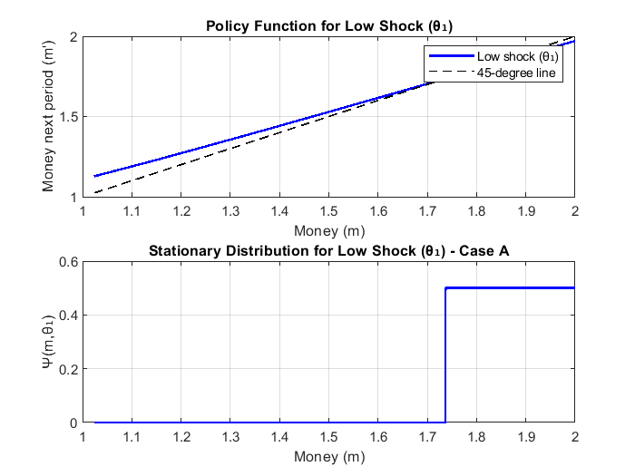

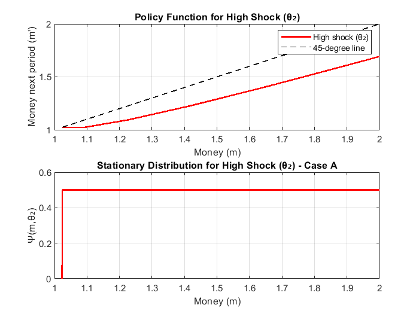

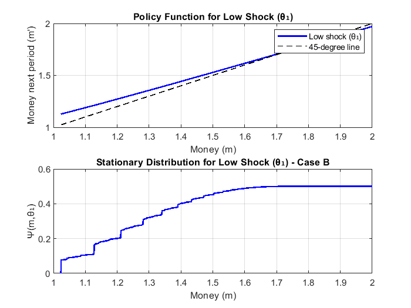

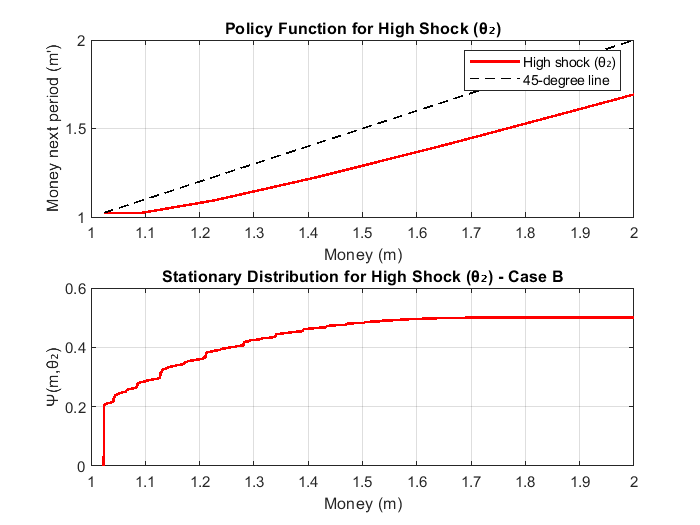

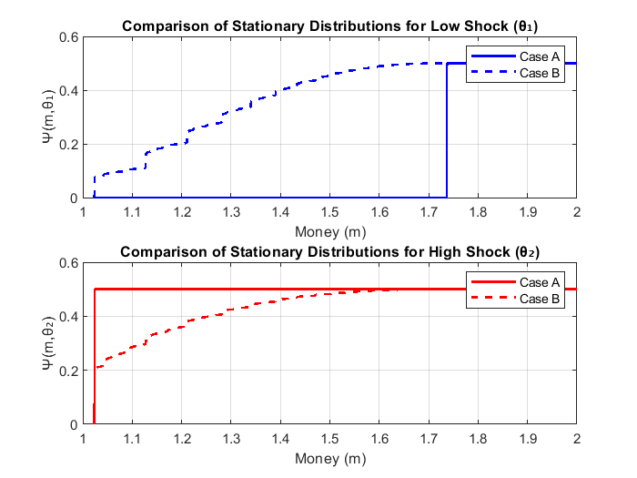

```matlab
% Parameters
beta = 0.98;
sigma = 2;
y = 1; % Fixed endowment
tau = 0.0234;
gamma = 0.02;
theta_1 = 0.74;
theta_2 = 1.36;

% Transition matrix
% Transition prob starting on theta_1
p11 = 0.73;
p21 = 1 - p11;
% Transition probabilities starting in theta_2
p22 = 0.73;
p12 = 1 - p22;

Np = 1000; % Size of the grid
mp_min = y + tau; % CIA constraint (m' = y + tau)
mp_max = 2; % Maximum money level (optional)

% Create the grid of m
mgrid = linspace(mp_min, mp_max, Np)';

% Maximum number of iterations
Nk = 1000;

% Distribution parameters
% Finer grid for the distribution (twice as many points)
Dp = 2*Np-1;
dist_mgrid = linspace(mp_min, mp_max, Dp)';

Dk = 1000; % Maximum number of distribution iterations

% Create a transition matrix
QQ = [p11 p21; p12 p22];
nshocks = 2;

% Create the ergodic distribution
prob = QQ - eye(nshocks);
prob(:, nshocks) = ones(nshocks, 1);
a = zeros(nshocks, 1);
a(nshocks) = 1;
epr = linsolve(prob', a);


%% Case A Implementation
% Initialize distributions for both cases
F1_a = zeros(Dp, 1);
F2_a = zeros(Dp, 1);

% Create uniform distribution as initial guess
unif_dist = (dist_mgrid - dist_mgrid(1)) / (dist_mgrid(end) - dist_mgrid(1));

% Initial distributions
F1_a = epr(1) * unif_dist;
F2_a = epr(2) * unif_dist;

% Pre-compute the inverse policy functions for efficiency
% We need to find g^-1(m') for each m' in our grid
g1_unique = unique(g_pol_1, 'stable');
g2_unique = unique(g_pol_2, 'stable');

% Find the corresponding m values for each unique g value
m1_values = zeros(size(g1_unique));
m2_values = zeros(size(g2_unique));

for i = 1:length(g1_unique)
    idx = find(g_pol_1 == g1_unique(i), 1, 'first');
    m1_values(i) = mgrid(idx);
end

for i = 1:length(g2_unique)
    idx = find(g_pol_2 == g2_unique(i), 1, 'first');
    m2_values(i) = mgrid(idx);
end

% Case A iterations
disp('Starting Case A iterations...');
for iter = 1:Dk
    F1_a_new = zeros(Dp, 1);
    F2_a_new = zeros(Dp, 1);

    for j = 1:Dp
        mp = dist_mgrid(j);

        % Find g^-1(mp) for each shock
        % For low shock (θ₁)
        if mp <= g_pol_1(1)
            F1_a_new(j) = 0;
        elseif mp >= g_pol_1(end)
            F1_a_new(j) = F1_a(end);
        else
            % Find g^-1(mp, θ₁)
            m_value = interp1(g1_unique, m1_values, mp, 'linear');
            % Find Ψₛ(g^-1(mp, θ₁), θ₁)
            F1_a_new(j) = interp1(dist_mgrid, F1_a, m_value, 'linear');
        end

        % For high shock (θ₂)
        if mp <= g_pol_2(1)
            F2_a_new(j) = 0;
        elseif mp >= g_pol_2(end)
            F2_a_new(j) = F2_a(end);
        else
            % Find g^-1(mp, θ₂)
            m_value = interp1(g2_unique, m2_values, mp, 'linear');
            % Find Ψₛ(g^-1(mp, θ₂), θ₂)
            F2_a_new(j) = interp1(dist_mgrid, F2_a, m_value, 'linear');
        end
    end

    % Check convergence
    diff1 = max(abs(F1_a_new - F1_a));
    diff2 = max(abs(F2_a_new - F2_a));

    % Update distributions
    F1_a = F1_a_new;
    F2_a = F2_a_new;

    if mod(iter, 100) == 0
        disp(['Iteration ' num2str(iter) ', Max diff: ' num2str(max(diff1, diff2))]);
    end

    if max(diff1, diff2) < 1e-8
        disp(['Case A converged after ' num2str(iter) ' iterations']);
        break;
    end

    if iter == Dk
        disp('Case A reached maximum iterations without converging');
    end
end

%% Case B Implementation
%% Case B Implementation (Improved)
% Initialize distributions for Case B
F1_b = zeros(Dp, 1);
F2_b = zeros(Dp, 1);

% Initial distributions (same as Case A)
F1_b = epr(1) * unif_dist;
F2_b = epr(2) * unif_dist;

% Case B iterations
disp('Starting Case B iterations...');
for iter = 1:Dk
    F1_b_new = zeros(Dp, 1);
    F2_b_new = zeros(Dp, 1);

    for j = 1:Dp
        mp = dist_mgrid(j);

        % The recursive equation for Case B is:
        % Ψₛ₊₁(m',θⱼ) = ∑ Q(θ,θⱼ)Ψₛ(g⁻¹(m',θ),θ)

        % Low shock (j=1)

        % Contribution from transition θ₁ → θ₁
        if mp <= g_pol_1(1)
            val1_1 = 0;
        elseif mp >= g_pol_1(end)
            val1_1 = p11 * F1_b(end);  % If mp is beyond the range, use the last value
        else
            % Find g^-1(mp, θ₁)
            m_value = interp1(g1_unique, m1_values, mp, 'linear');
            % Find Ψₛ(g^-1(mp, θ₁), θ₁) and multiply by p11
            val1_1 = p11 * interp1(dist_mgrid, F1_b, m_value, 'linear');
        end

        % Contribution from transition θ₂ → θ₁
        if mp <= g_pol_2(1)
            val1_2 = 0;
        elseif mp >= g_pol_2(end)
            val1_2 = p12 * F2_b(end);  % If mp is beyond the range, use the last value
        else
            % Find g^-1(mp, θ₂)
            m_value = interp1(g2_unique, m2_values, mp, 'linear');
            % Find Ψₛ(g^-1(mp, θ₂), θ₂) and multiply by p12
            val1_2 = p12 * interp1(dist_mgrid, F2_b, m_value, 'linear');
        end

        val1 = val1_1 + val1_2;
        F1_b_new(j) = val1;

        % High shock (j=2)

        % Contribution from transition θ₁ → θ₂
        if mp <= g_pol_1(1)
            val2_1 = 0;
        elseif mp >= g_pol_1(end)
            val2_1 = p21 * F1_b(end);  % If mp is beyond the range, use the last value
        else
            % Find g^-1(mp, θ₁)
            m_value = interp1(g1_unique, m1_values, mp, 'linear');
            % Find Ψₛ(g^-1(mp, θ₁), θ₁) and multiply by p21
            val2_1 = p21 * interp1(dist_mgrid, F1_b, m_value, 'linear');
        end

        % Contribution from transition θ₂ → θ₂
        if mp <= g_pol_2(1)
            val2_2 = 0;
        elseif mp >= g_pol_2(end)
            val2_2 = p22 * F2_b(end);  % If mp is beyond the range, use the last value
        else
            % Find g^-1(mp, θ₂)
            m_value = interp1(g2_unique, m2_values, mp, 'linear');
            % Find Ψₛ(g^-1(mp, θ₂), θ₂) and multiply by p22
            val2_2 = p22 * interp1(dist_mgrid, F2_b, m_value, 'linear');
        end

        val2 = val2_1 + val2_2;
        F2_b_new(j) = val2;
    end

    % Check convergence
    diff1 = max(abs(F1_b_new - F1_b));
    diff2 = max(abs(F2_b_new - F2_b));

    % Update distributions
    F1_b = F1_b_new;
    F2_b = F2_b_new;

    if mod(iter, 100) == 0
        disp(['Iteration ' num2str(iter) ', Max diff: ' num2str(max(diff1, diff2))]);
    end

    if max(diff1, diff2) < 1e-8
        disp(['Case B converged after ' num2str(iter) ' iterations']);
        break;
    end

    if iter == Dk
        disp('Case B reached maximum iterations without converging');
    end
end

%% Plotting
% Plot results for Case A
figure;
subplot(2,1,1);
plot(mgrid, g_pol_1, 'b-', 'LineWidth', 1.5); hold on;
plot(mgrid, mgrid, 'k--', 'LineWidth', 1); % 45-degree line
grid on;
xlabel('Money (m)');
ylabel('Money next period (m'')');
legend('Low shock (θ₁)', '45-degree line');
title('Policy Function for Low Shock (θ₁)');

subplot(2,1,2);
plot(dist_mgrid, F1_a, 'b-', 'LineWidth', 1.5);
grid on;
xlabel('Money (m)');
ylabel('Ψ(m,θ₁)');
title('Stationary Distribution for Low Shock (θ₁) - Case A');

figure;
subplot(2,1,1);
plot(mgrid, g_pol_2, 'r-', 'LineWidth', 1.5); hold on;
plot(mgrid, mgrid, 'k--', 'LineWidth', 1); % 45-degree line
grid on;
xlabel('Money (m)');
ylabel('Money next period (m'')');
legend('High shock (θ₂)', '45-degree line');
title('Policy Function for High Shock (θ₂)');

subplot(2,1,2);
plot(dist_mgrid, F2_a, 'r-', 'LineWidth', 1.5);
grid on;
xlabel('Money (m)');
ylabel('Ψ(m,θ₂)');
title('Stationary Distribution for High Shock (θ₂) - Case A');


% Plot results for Case B
figure;
subplot(2,1,1);
plot(mgrid, g_pol_1, 'b-', 'LineWidth', 1.5); hold on;
plot(mgrid, mgrid, 'k--', 'LineWidth', 1); % 45-degree line
grid on;
xlabel('Money (m)');
ylabel('Money next period (m'')');
legend('Low shock (θ₁)', '45-degree line');
title('Policy Function for Low Shock (θ₁)');

subplot(2,1,2);
plot(dist_mgrid, F1_b, 'b-', 'LineWidth', 1.5);
grid on;
xlabel('Money (m)');
ylabel('Ψ(m,θ₁)');
title('Stationary Distribution for Low Shock (θ₁) - Case B');

figure;
subplot(2,1,1);
plot(mgrid, g_pol_2, 'r-', 'LineWidth', 1.5); hold on;
plot(mgrid, mgrid, 'k--', 'LineWidth', 1); % 45-degree line
grid on;
xlabel('Money (m)');
ylabel('Money next period (m'')');
legend('High shock (θ₂)', '45-degree line');
title('Policy Function for High Shock (θ₂)');

subplot(2,1,2);
plot(dist_mgrid, F2_b, 'r-', 'LineWidth', 1.5);
grid on;
xlabel('Money (m)');
ylabel('Ψ(m,θ₂)');
title('Stationary Distribution for High Shock (θ₂) - Case B');


% Plot distributions
figure;
subplot(2,1,1);
plot(dist_mgrid, F1_a, 'b-', 'LineWidth', 1.5); hold on;
plot(dist_mgrid, F1_b, 'b--', 'LineWidth', 1.5);
grid on;
xlabel('Money (m)');
ylabel('Ψ(m,θ₁)');
legend('Case A', 'Case B');
title('Comparison of Stationary Distributions for Low Shock (θ₁)');

subplot(2,1,2);
plot(dist_mgrid, F2_a, 'r-', 'LineWidth', 1.5); hold on;
plot(dist_mgrid, F2_b, 'r--', 'LineWidth', 1.5);
grid on;
xlabel('Money (m)');
ylabel('Ψ(m,θ₂)');
legend('Case A', 'Case B');
title('Comparison of Stationary Distributions for High Shock (θ₂)');
```

## **3. Computing equilibrium (120 points)**

Consider the same setup as in Questions 1 and 2, but omit the information that $ \tau = 0.0234 $.

### **Tasks**

**(a)** Find the equilibrium of the model. Use either the **iterative scheme** discussed in class or the **Bisection method**. (100 points)

**(b)** Plot policy functions and distributions in equilibrium. (20 points)

```
Convergence achieved after 71 iterations.
convergence achieved of F2
    74

Convergence achieved after 71 iterations.
convergence achieved of F2
    74

Convergence achieved after 71 iterations.
convergence achieved of F2
    74

Convergence achieved after 71 iterations.
convergence achieved of F2
    74

Convergence achieved after 71 iterations.
convergence achieved of F2
    74

Convergence achieved after 71 iterations.
convergence achieved of F2
    74

Convergence achieved after 71 iterations.
convergence achieved of F2
    74

money supply star found
    1.1923

     8
```

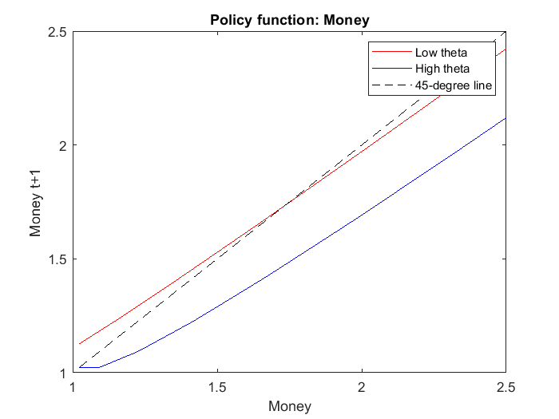

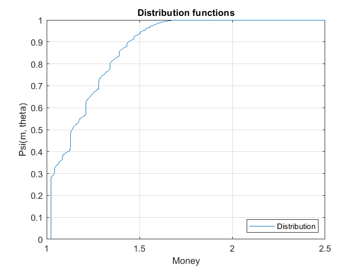

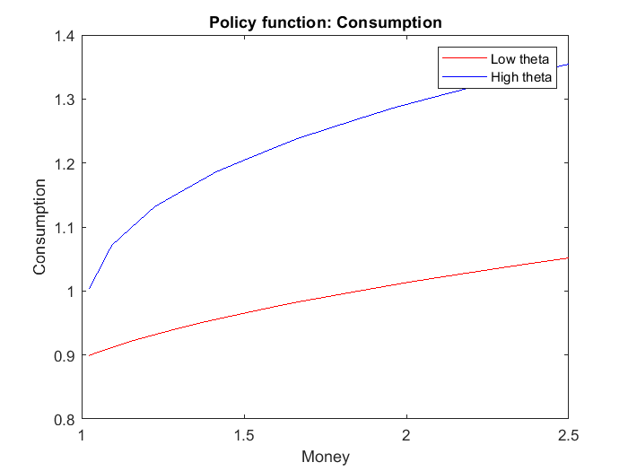

```matlab
%% Computing the equilibrium

clear; clc; close all;

% Same information as before but we don't have tau

% Parameters
beta = 0.98;
sigma = 2;
y = 1; % Fixed endowment
%tau = 0.0234; we don't have this
gamma = 0.02;
theta_1 = 0.74;
theta_2 = 1.36;

% Transition matrix
% Transition prob starting on theta_1
p11 = 0.73;
p21 = 1 - p11;

% Transition probabilities starting in theta_2
p22 = 0.73;
p12 = 1 - p22;

% Transition matrix
QQ = [p11 p21; p12 p22];

% Creating the placeholder for money supply and the first guess
TT = 200;
m_supply = zeros(TT,1);
m_supply(1) = 1.5; % Arbitrary, first guess

for s=1:TT+1

    % Use the guess in monery supply to get Tau
    tau = m_supply(s) * gamma / (1 + gamma);

    Np = 1000; % Size of the grid

    mp_min = y + tau; % CIA constraint (m' = y + tau)
    mp_max = 2.5;  % Maximum money level (optional)

    % Create the grid of m
    mgrid = linspace(mp_min, mp_max, Np)';

    % Maximum number of iterations
    Nk = 1000;


    % POLICY FUNCTIONS


    % Initial guesses of m
    g0_1 = mgrid;
    g0_2 = mgrid;

    % Preallocate memory for future iterations
    g_1 = zeros(Np, Nk);
    g_2 = zeros(Np, Nk);

    % First column is the initial guess
    g_1(:,1) = g0_1;
    g_2(:,1) = g0_2;

    for j = 1:Nk-1
        uprime_1 = theta_1 * ((mgrid ./ (1 + gamma)) + y + tau - g_1(:,j)) .^ (-sigma);
        uprime_2 = theta_2 * ((mgrid ./ (1 + gamma)) + y + tau - g_2(:,j)) .^ (-sigma);

        % Compute expectations under the Markov transition matrix
        EV_1 = ((beta/(1+gamma)) * (p11 * uprime_1' + p12 * uprime_2'))';
        EV_2 = ((beta/(1+gamma)) * (p21 * uprime_1' + p22 * uprime_2'))';

        % Compute mstar
        ms_1 = ((EV_1/theta_1) .^ (-1/sigma) + mgrid - y - tau) * (1+gamma);
        ms_2 = ((EV_2/theta_2) .^ (-1/sigma) + mgrid - y - tau) * (1+gamma);

        for i=1:Np
            if mgrid(i) <= ms_1(1)
                g_1(i,j+1) = mgrid(1);
            elseif mgrid(i) >= ms_1(Np)
                g_1(i, j+1) = mgrid(Np);
            else
                g_1(i, j+1) = interp1(ms_1, mgrid, mgrid(i), 'linear', 'extrap');
            end
        end

        for i=1:Np
            if mgrid(i) <= ms_2(1)
                g_2(i,j+1) = mgrid(1);
            elseif mgrid(i) >= ms_2(Np)
                g_2(i, j+1) = mgrid(Np);
            else
                g_2(i, j+1) = interp1(ms_2, mgrid, mgrid(i), 'linear', 'extrap');
            end
        end

        % Check convergence
        gdiff = max(abs([g_1(:,j+1); g_2(:,j+1)] - [g_1(:,j); g_2(:,j)]));
        if gdiff <= 1e-10
            disp("Convergence achieved after " + num2str(j) + " iterations.");
            g_pol_1 = g_1(:, j+1);
            g_pol_2 = g_2(:, j+1);
            break;
        end
    end

    % If convergence isn't achieved, store final iteration values
    if gdiff > 1e-10
        disp("Maximum iterations reached without convergence.");
        g_pol_1 = g_1(:, end);
        g_pol_2 = g_2(:, end);
    end



    % DISTRIBUTIONS

    % Distribution parameters
    % New grid for the distribution
    Dp = 2*Np-1;
    dist_mgrid = linspace(mp_min, mp_max, Dp)';

    Dk = 10000; % Maximum number of distribution iterations

    % Other options: normal dist
    unif_dist = (dist_mgrid - dist_mgrid(1)) / (dist_mgrid(Dp) - dist_mgrid(1));


    % Create a transition matrix with the prob
    QQ = [p11 p21; p12 p22];
    nshocks = 2;

    % Create the ergodic distribution (cn 7)
    % The ergodic distribution (or stationary distribution) of a Markov chain
    % represents the long-run probability of being in each state when the system
    % reaches equilibrium. It tells us how often, on average, we would expect the
    % system to be in each state after a long enough period.

    % Linearization of the system of equations (eye is the identity matrix of
    % size nshocks)
    % pi1 = 0.73 * pi1 + 0.27 * pi2
    % pi2 = 0.27 * pi1 + 0.73 * pi2

    prob = QQ - eye(nshocks);
    % [(0.73 - 1)  0.27]
    % [0.27  (0.73 - 1)]

    % but this has infinite solutions, hence we first enforce pi1 + pi2 = 1
    % by enforcing the last column to be 1 (normalization condition)
    % This is the same as normalizing the eigenvector to sum to 1 in tauchen's
    % [-0.27  1]
    % [ 0.27  1]

    prob(:, nshocks) = ones(nshocks, 1);

    % On the other side of the equality, we would have a = [0 1] to solve
    % for the ergodic distribution over states that remain unchanged over the
    % long run and sum up to 1

    a = zeros(nshocks, 1);
    a(nshocks) = 1;

    % Ergodic distribution
    epr = linsolve(prob', a);

    % Placeholders for my distributions
    % initial_dist = (psi_0(m1) + [psi_0(mM) - psi_0(m1)] * unif_dist) * epr
    % but since psi_0(mM)=1 and psi_0(m1)=0
    F1 = zeros(Dp, Dk);
    F1(:,1) = epr(1) * unif_dist; %epr(1) is for the ergodic dist for theta_1

    F2 = zeros(Dp, Dk);
    F2(:,1) = epr(2) * unif_dist; %epr(2) is for the ergodic dist for theta_2


    % Iterations for convergence
    for i = 1:Dk-1
        for j=1:Dp

            % For low shock

            if dist_mgrid(j) < g_pol_1(1)
                val_1 = 0;
            elseif dist_mgrid(j) > g_pol_1(Np)
                val_1 = epr(1);
            else
                % This is to obtain the unique values of the policy
                % function and extract the index for each one of these values.
                [g1r, ind_1] = unique(g_pol_1, "last");

                % For the first interpolation I want an interpolated value for dist_mgrid(j)
                % using the function values (gr1) of mgrid(ind_1).
                % For the second interpolation I want an interpolated value of
                % the distribution function F1(:,i) at that query point (new dgrid).

                % The reason g1r is X and mgrid(ind_1) is Y is because I want
                % the value in mgrid (inverse policy function used)

                % Otherwise dist_mgrid is X and F1(:,i) is Y because I
                % want the value of the distribution such that I can use it
                % as my new value of the function in i+1.

                val_1 = interp1(dist_mgrid, F1(:,i), interp1(g1r, mgrid(ind_1), dist_mgrid(j), "linear"), "linear");

            end

            % For high shock

            if dist_mgrid(j) <= g_pol_2(1)
                val_2 = 0;
            elseif dist_mgrid(j) >= g_pol_2(Np)
                val_2 = epr(2);
            else
                [g2r, ind_2] = unique(g_pol_2, "last");

                val_2 = interp1(dist_mgrid, F2(:,i), interp1(g2r, mgrid(ind_2), dist_mgrid(j), "linear"), "linear");
            end

            % New distribution
            F1(j, i+1) = val_1 * QQ(1,1) + val_2 * QQ(2,1);
            F2(j, i+1) = val_1 * QQ(1,2) + val_2 * QQ(2,2);

        end

        diff1 = max(abs(F1(:,i+1)-F1(:,i)));
        diff2 = max(abs(F2(:,i+1)-F2(:,i)));

        F1_dist = F1(:,i+1);
        F2_dist = F2(:,i+1);

        if diff1 <= 1e-10
            disp("convergence achieved of F1");
            disp(i);
            break
        end

        if diff2 <= 1e-10
            disp("convergence achieved of F2");
            disp(i);
            break
        end
    end


    % EQUILIBRIUM

    dopt = zeros(Dp, nshocks);

    dopt(:,1) = F1_dist;
    dopt(:,2) = F2_dist;

    % Added the two optimal distribution functions (make them a single
    % distribution)
    FO = sum(dopt, 2);
    % Average money holdings (Real balances = money demand)
    % Cobbweb way of finding equilibrium
    RB = (FO(2:Dp) - FO(1:Dp-1))' * ((dist_mgrid(2:Dp) + dist_mgrid(1:Dp-1))/2) + (FO(1) * dist_mgrid(1));

    % This is why the initial for loop is up to TT+1 (money supply)
    % money supply = money demand
    m_supply(s+1) = RB;

    if abs(m_supply(s+1) - m_supply(s)) <= 1e-10
        disp("money supply star found")
        disp(m_supply(s));
        disp(s+1);
        break;
    end

end




% Plotting money policy function
figure;
plot(mgrid, g_pol_1, 'r'); hold on;
plot(mgrid, g_pol_2, 'b');
plot(mgrid, mgrid, 'k--'); % 45-degree line
xlabel('Money');
ylabel('Money t+1');
legend('Low theta', 'High theta', '45-degree line');
title('Policy function: Money');

% Plotting distribution function
figure;
plot(dist_mgrid, FO);
grid on;
xlabel('Money');
ylabel('Psi(m, theta)');
title('Distribution functions');
legend({'Distribution'}, 'location', 'southeast');


% Compute policy functions for consumption
c_pol_1 = (mgrid / (1 + gamma)) + y + tau - g_pol_1;
c_pol_2 = (mgrid / (1 + gamma)) + y + tau - g_pol_2;

% Interpolated consumption defined on the grid dgrid
icons_1 = interp1(mgrid, c_pol_1, dist_mgrid);
icons_2 = interp1(mgrid, c_pol_2, dist_mgrid);

agicons_1 = (dopt(2:Dp, 1) - dopt(1:Dp-1, 1))' * ((icons_1(2:Dp) + icons_1(1:Dp-1))/2) + (dopt(1, 1) * icons_1(1));
agicons_2 = (dopt(2:Dp, 2) - dopt(1:Dp-1, 2))' * ((icons_2(2:Dp) + icons_2(1:Dp-1))/2) + (dopt(1, 2) * icons_2(1));

%Aggregate consumption
agicons = agicons_1 + agicons_2;

% Plotting consumption function
figure;
plot(mgrid, c_pol_1, 'r'); hold on;
plot(mgrid, c_pol_2, 'b');
xlabel('Money');
ylabel('Consumption');
legend('Low theta', 'High theta');
title('Policy function: Consumption');
```

```
Starting bisection method to find equilibrium money supply...
Iteration 1: Money supply = 2.750000, Excess demand = -1.521697, Interval width = 2.250000
Iteration 2: Money supply = 1.625000, Excess demand = -0.422370, Interval width = 1.125000
Iteration 3: Money supply = 1.062500, Excess demand = 0.127285, Interval width = 0.562500
Iteration 4: Money supply = 1.343750, Excess demand = -0.147524, Interval width = 0.281250
Iteration 5: Money supply = 1.203125, Excess demand = -0.010127, Interval width = 0.140625
Iteration 6: Money supply = 1.132812, Excess demand = 0.058581, Interval width = 0.070312
Iteration 7: Money supply = 1.167969, Excess demand = 0.024226, Interval width = 0.035156
Iteration 8: Money supply = 1.185547, Excess demand = 0.007049, Interval width = 0.017578
Iteration 9: Money supply = 1.194336, Excess demand = -0.001540, Interval width = 0.008789
Iteration 10: Money supply = 1.189941, Excess demand = 0.002754, Interval width = 0.004395
Iteration 11: Money supply = 1.192139, Excess demand = 0.000607, Interval width = 0.002197
Iteration 12: Money supply = 1.193237, Excess demand = -0.000466, Interval width = 0.001099
Iteration 13: Money supply = 1.192688, Excess demand = 0.000070, Interval width = 0.000549
Iteration 14: Money supply = 1.192963, Excess demand = -0.000198, Interval width = 0.000275
Iteration 15: Money supply = 1.192825, Excess demand = -0.000064, Interval width = 0.000137
Iteration 16: Money supply = 1.192757, Excess demand = 0.000003, Interval width = 0.000069
Iteration 17: Money supply = 1.192791, Excess demand = -0.000030, Interval width = 0.000034
Iteration 18: Money supply = 1.192774, Excess demand = -0.000013, Interval width = 0.000017
Iteration 19: Money supply = 1.192765, Excess demand = -0.000005, Interval width = 0.000009
Iteration 20: Money supply = 1.192761, Excess demand = -0.000001, Interval width = 0.000004
Iteration 21: Money supply = 1.192759, Excess demand = 0.000001, Interval width = 0.000002
Iteration 22: Money supply = 1.192760, Excess demand = 0.000000, Interval width = 0.000001
Iteration 23: Money supply = 1.192760, Excess demand = -0.000000, Interval width = 0.000001

Equilibrium money supply found: 1.192760 after 23 iterations
Equilibrium tau: 0.023387
```

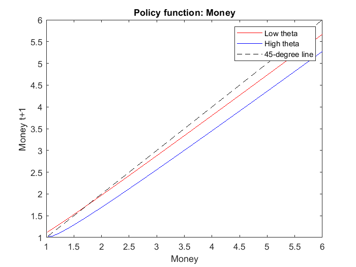

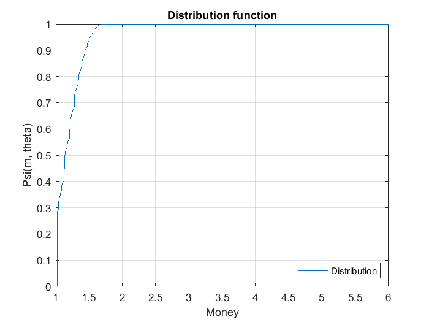

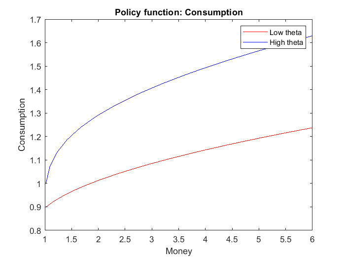

```matlab
%% Equilibrium using the bisection method


clear; clc; close all;

% Parameters
beta = 0.98;
sigma = 2;
y = 1; % Fixed endowment
gamma = 0.02;
theta_1 = 0.74;
theta_2 = 1.36;

% Transition matrix
% Transition prob starting on theta_1
p11 = 0.73;
p21 = 1 - p11;

% Transition probabilities starting in theta_2
p22 = 0.73;
p12 = 1 - p22;

% Transition matrix
QQ = [p11 p21; p12 p22];

% Bisection method parameters
m_min = 0.5;  % Lower bound for money supply
m_max = 5.0;  % Upper bound for money supply
tol = 1e-6;   % Tolerance for convergence
max_iter = 100; % Maximum iterations for bisection

% Bisection algorithm to find equilibrium money supply
iter = 0;
diff = tol + 1;  % Initialize difference above tolerance

disp('Starting bisection method to find equilibrium money supply...');

while (diff > tol && iter < max_iter)
    iter = iter + 1;

    % Compute midpoint
    m_mid = (m_min + m_max) / 2;

    % Calculate excess demand at m_min and m_mid
    excess_min = compute_excess_demand(m_min, gamma, y, beta, sigma, theta_1, theta_2, QQ);
    excess_mid = compute_excess_demand(m_mid, gamma, y, beta, sigma, theta_1, theta_2, QQ);

    % Check if the root is in the left or right subinterval
    if excess_min * excess_mid <= 0
        m_max = m_mid;
    else
        m_min = m_mid;
    end

    % Compute new difference for convergence check
    diff = m_max - m_min;

    fprintf('Iteration %d: Money supply = %.6f, Excess demand = %.6f, Interval width = %.6f\n', ...
        iter, m_mid, excess_mid, diff);
end

% Final equilibrium money supply
m_equilibrium = (m_min + m_max) / 2;
fprintf('\nEquilibrium money supply found: %.6f after %d iterations\n', m_equilibrium, iter);

% Calculate tau at equilibrium
tau_equilibrium = m_equilibrium * gamma / (1 + gamma);
fprintf('Equilibrium tau: %.6f\n', tau_equilibrium);

% Now calculate policy functions and distributions at equilibrium
[g_pol_1, g_pol_2, FO, dist_mgrid, c_pol_1, c_pol_2, mgrid] = compute_policy_and_distribution(m_equilibrium, gamma, y, beta, sigma, theta_1, theta_2, QQ);

% Define the function to compute excess demand (money demand - money supply)
function excess = compute_excess_demand(money_supply, gamma, y, beta, sigma, theta_1, theta_2, QQ)
    % First get policy functions and distributions
    [~, ~, FO, dist_mgrid, ~, ~, ~] = compute_policy_and_distribution(money_supply, gamma, y, beta, sigma, theta_1, theta_2, QQ);

    % Calculate money demand (average money holdings)
    Dp = length(dist_mgrid);
    money_demand = (FO(2:Dp) - FO(1:Dp-1))' * ((dist_mgrid(2:Dp) + dist_mgrid(1:Dp-1))/2) + (FO(1) * dist_mgrid(1));

    % Compute excess demand
    excess = money_demand - money_supply;
end



% Function to compute policy functions and distributions given a money supply
function [g_pol_1, g_pol_2, FO, dist_mgrid, c_pol_1, c_pol_2, mgrid] = compute_policy_and_distribution(money_supply, gamma, y, beta, sigma, theta_1, theta_2, QQ)
    % Use the money supply to get tau
    tau = money_supply * gamma / (1 + gamma);

    % Grid parameters
    Np = 1000; % Size of the grid
    mp_min = y + tau; % CIA constraint (m' = y + tau)
    mp_max = 6;  % Maximum money level (optional)

    % Create the grid of m
    mgrid = linspace(mp_min, mp_max, Np)';

    % Maximum number of iterations for policy function
    Nk = 1000;

    % POLICY FUNCTIONS
    % Initial guesses of m
    g0_1 = mgrid;
    g0_2 = mgrid;

    % Preallocate memory for future iterations
    g_1 = zeros(Np, Nk);
    g_2 = zeros(Np, Nk);

    % First column is the initial guess
    g_1(:,1) = g0_1;
    g_2(:,1) = g0_2;

    for j = 1:Nk-1
        uprime_1 = theta_1 * ((mgrid ./ (1 + gamma)) + y + tau - g_1(:,j)) .^ (-sigma);
        uprime_2 = theta_2 * ((mgrid ./ (1 + gamma)) + y + tau - g_2(:,j)) .^ (-sigma);

        % Compute expectations under the Markov transition matrix
        EV_1 = ((beta/(1+gamma)) * (QQ(1,1) * uprime_1' + QQ(1,2) * uprime_2'))';
        EV_2 = ((beta/(1+gamma)) * (QQ(2,1) * uprime_1' + QQ(2,2) * uprime_2'))';

        % Compute mstar
        ms_1 = ((EV_1/theta_1) .^ (-1/sigma) + mgrid - y - tau) * (1+gamma);
        ms_2 = ((EV_2/theta_2) .^ (-1/sigma) + mgrid - y - tau) * (1+gamma);

        for i=1:Np
            if mgrid(i) <= ms_1(1)
                g_1(i,j+1) = mgrid(1);
            elseif mgrid(i) >= ms_1(Np)
                g_1(i, j+1) = mgrid(Np);
            else
                g_1(i, j+1) = interp1(ms_1, mgrid, mgrid(i), 'linear', 'extrap');
            end
        end

        for i=1:Np
            if mgrid(i) <= ms_2(1)
                g_2(i,j+1) = mgrid(1);
            elseif mgrid(i) >= ms_2(Np)
                g_2(i, j+1) = mgrid(Np);
            else
                g_2(i, j+1) = interp1(ms_2, mgrid, mgrid(i), 'linear', 'extrap');
            end
        end

        % Check convergence
        gdiff = max(abs([g_1(:,j+1); g_2(:,j+1)] - [g_1(:,j); g_2(:,j)]));
        if gdiff <= 1e-10
            %disp(['Policy function convergence achieved after ', num2str(j), ' iterations.']);
            g_pol_1 = g_1(:, j+1);
            g_pol_2 = g_2(:, j+1);
            break;
        end
    end

    % If convergence isn't achieved, store final iteration values
    if j == Nk-1
        %disp('Maximum iterations reached without convergence for policy functions.');
        g_pol_1 = g_1(:, end);
        g_pol_2 = g_2(:, end);
    end

    % DISTRIBUTIONS
    % Distribution parameters
    % New grid for the distribution
    Dp = 2*Np-1;
    dist_mgrid = linspace(mp_min, mp_max, Dp)';

    Dk = 10000; % Maximum number of distribution iterations

    % Other options: normal dist
    unif_dist = (dist_mgrid - dist_mgrid(1)) / (dist_mgrid(Dp) - dist_mgrid(1));

    % Create the ergodic distribution
    prob = QQ - eye(2);
    prob(:, 2) = ones(2, 1);

    a = zeros(2, 1);
    a(2) = 1;

    % Ergodic distribution
    epr = linsolve(prob', a);

    % Placeholders for distributions
    F1 = zeros(Dp, Dk);
    F1(:,1) = epr(1) * unif_dist;

    F2 = zeros(Dp, Dk);
    F2(:,1) = epr(2) * unif_dist;

    % Iterations for convergence
    for i = 1:Dk-1
        for j=1:Dp
            % For low shock
            if dist_mgrid(j) < g_pol_1(1)
                val_1 = 0;
            elseif dist_mgrid(j) > g_pol_1(Np)
                val_1 = epr(1);
            else
                [g1r, ind_1] = unique(g_pol_1, "last");
                val_1 = interp1(dist_mgrid, F1(:,i), interp1(g1r, mgrid(ind_1), dist_mgrid(j), "linear"), "linear");
            end

            % For high shock
            if dist_mgrid(j) <= g_pol_2(1)
                val_2 = 0;
            elseif dist_mgrid(j) >= g_pol_2(Np)
                val_2 = epr(2);
            else
                [g2r, ind_2] = unique(g_pol_2, "last");
                val_2 = interp1(dist_mgrid, F2(:,i), interp1(g2r, mgrid(ind_2), dist_mgrid(j), "linear"), "linear");
            end

            % New distribution
            F1(j, i+1) = val_1 * QQ(1,1) + val_2 * QQ(2,1);
            F2(j, i+1) = val_1 * QQ(1,2) + val_2 * QQ(2,2);
        end

        diff1 = max(abs(F1(:,i+1)-F1(:,i)));
        diff2 = max(abs(F2(:,i+1)-F2(:,i)));

        F1_dist = F1(:,i+1);
        F2_dist = F2(:,i+1);

        if diff1 <= 1e-10 && diff2 <= 1e-10
            %disp(['Distribution convergence achieved after ', num2str(i), ' iterations.']);
            break;
        end
    end

    if i == Dk-1
        %disp('Maximum iterations reached without convergence for distributions.');
    end

    % Combining distributions
    dopt = zeros(Dp, 2);
    dopt(:,1) = F1_dist;
    dopt(:,2) = F2_dist;

    % Total distribution
    FO = sum(dopt, 2);

    % Compute policy functions for consumption
    c_pol_1 = (mgrid / (1 + gamma)) + y + tau - g_pol_1;
    c_pol_2 = (mgrid / (1 + gamma)) + y + tau - g_pol_2;

    % Interpolate consumption to the distribution grid
    c_pol_1 = interp1(mgrid, c_pol_1, dist_mgrid, 'linear', 'extrap');
    c_pol_2 = interp1(mgrid, c_pol_2, dist_mgrid, 'linear', 'extrap');
end

% Plotting money policy function
figure;
plot(mgrid, g_pol_1, 'r'); hold on;
plot(mgrid, g_pol_2, 'b');
plot(mgrid, mgrid, 'k--'); % 45-degree line
xlabel('Money');
ylabel('Money t+1');
legend('Low theta', 'High theta', '45-degree line');
title('Policy function: Money');

% Plotting distribution function
figure;
plot(dist_mgrid, FO);
grid on;
xlabel('Money');
ylabel('Psi(m, theta)');
title('Distribution function');
legend({'Distribution'}, 'location', 'southeast');

% Plotting consumption function
figure;
plot(dist_mgrid, c_pol_1, 'r'); hold on;
plot(dist_mgrid, c_pol_2, 'b');
xlabel('Money');
ylabel('Consumption');
legend('Low theta', 'High theta');
title('Policy function: Consumption');
```